# Federalismo brasileiro

Aspectos para um modelo de análise

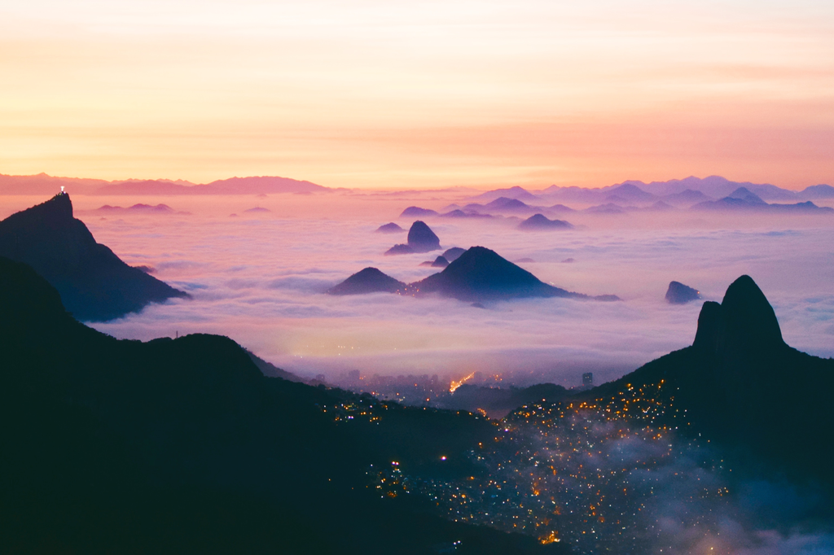

Foto por Noah Cellura em [Unsplash](https://unsplash.com/photos/BNK525WM4BA)

## O federalismo no Brasil

A constituição brasileira indica que estamos organizados em uma federação. Esse modelo de organização do Estado é caracterizado principalmente pela autonomia política e administrativa dos Estados-Membros.

No caso brasileiro compõem a federação os seguintes entes: a União, Estados, Distrito Federal e Municípios.

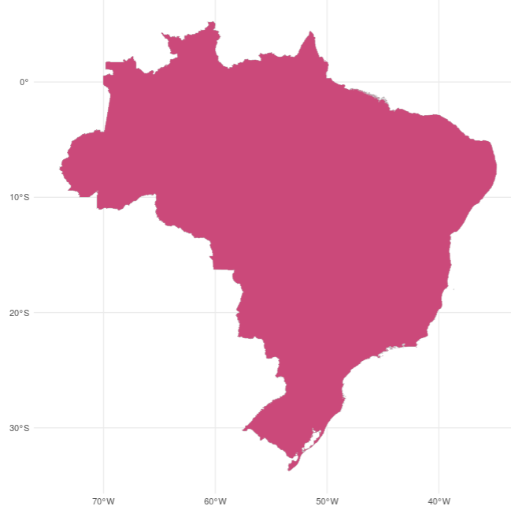

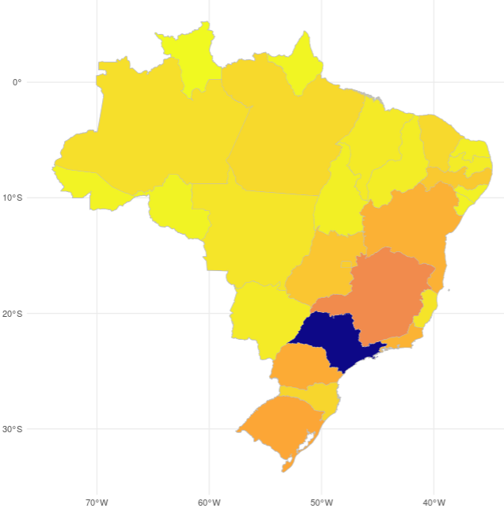

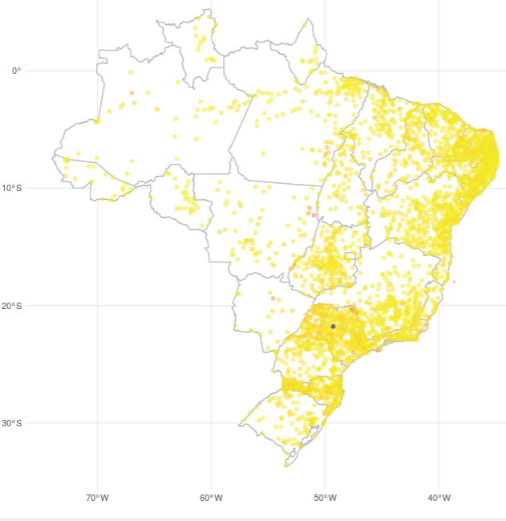

Mapas representando os entes federativos brasileiros. Fonte: [Meu Siconfi](https://meusiconfi.tesouro.gov.br/Interface_rsiconfi.rmd)

A descentralização associada à autonomia política e administrativa dos entes federativos implica numa série de fatores que determinam a evidenciação de soluções para os problemas que tipicamente são objetivados na organização federativa, assim como as eventuais disfunções.

O intuito desse texto é apresentar esses faotres e buscar operacionalizá-los de forma que se possa construir um modelo analítico que apoie estudos sobre diversos aspectos específicos do federalismo no Brasil.

## Um modelo analítico para estudos sobre federalismo

**Autonomia concedida aos entes**

O primeiro elemento do modelo diz respeito a autonomia administrativa, financeira e legislativa que é garantida aos entes federativos. Vale lembrar aqui o que diz a constituuição a respeito disso:

- A União tem competências privativas, definidas no artigo 22 da Constituição, que lhe conferem a responsabilidade pela soberania e a integração nacional, tais como legislar sobre

I – direito civil, comercial, penal, processual, eleitoral, agrário, marítimo, aeronáutico, espacial e do trabalho; VI – serviço monetário e de medidas, títulos e garantias dos metais; XV – emigração e imigração, entrada, extradição e expulsão de estrangeiros; XXVIII – Defesa territorial, defesa aeroespacial, defesa marítima, defesa civil e mobilização nacional.

- Os Municípios têm competências privativas associadas a serviços públicos de caráter local (artigo 30 da Constituição Federal), tais como o transporte coletivo e as leis de parcelamento do solo.
- O artigo 23 da Constituição Federal lista os assuntos que são de competência comum das três esferas, o que significa que precisa haver coordenação de esforços. Por exemplo, tem-se: a saúde e assistência pública; a proteção ambiental; o combate à pobreza e a educação para o trânsito.

Entende-se ainda que os Estados terão responsabilidades pelas funções de governo que não são explicitados pela constituição.

Por fim vale lembrar ainda que a autonomia financeira e orçamentária para os entes federativos é relativizada com a Lei de Responsabilidade Fiscal (LRF).

No nosso modelo, a autonomia será avaliada a partir de dados que demonstrem os gastos dos diversos níveis de governo por função, os impactos da LRF sobre a autonomia financeira e orçamentária e ainda as responsabilidades desses níveis na condução das politicas públicas. As duas figuras abaixo mostram um primeiro panorama dessa distribuição de gastos.

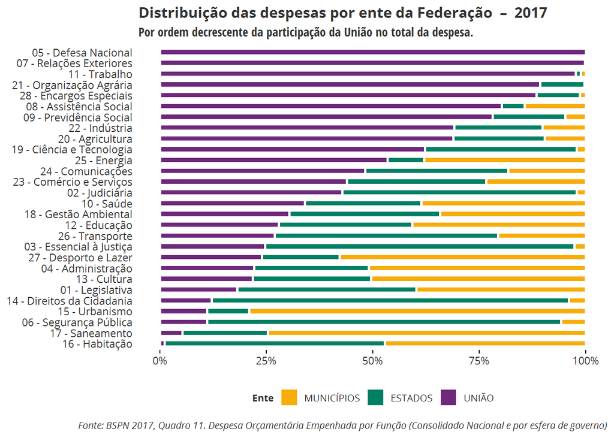

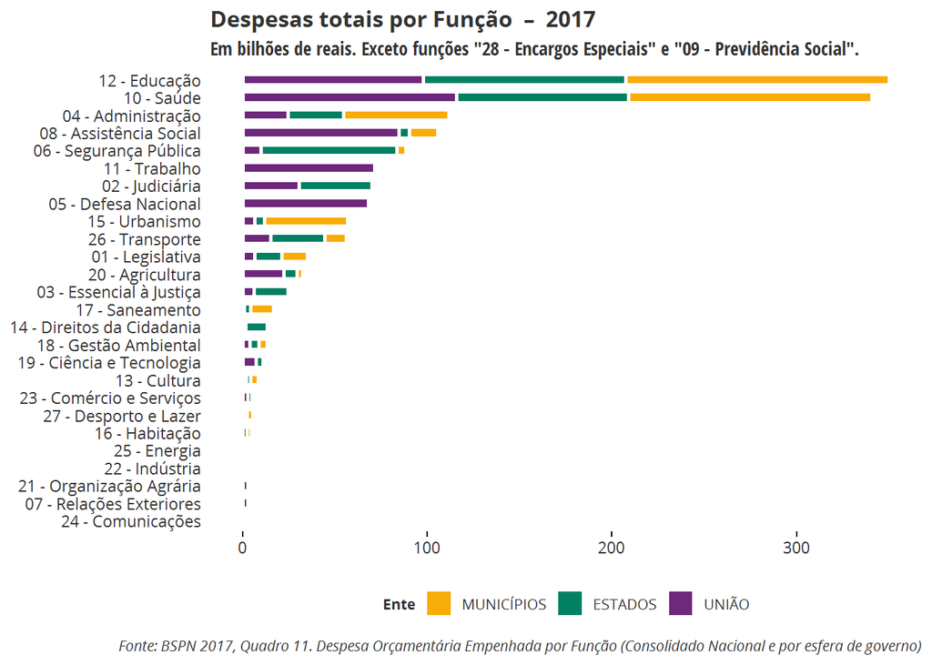

Despesas nas funções de governo por nível federativo Fonte: [Uma história sobre o BSPN-2017](https://www.tesourotransparente.gov.br/historias/bspn)

Como se vê, fica demonstrado que os entes federativos cumprem, pelo menos do ponto de vista das desepsas, o que era esperado em relação às atribuições de cada nivel ferderativo em relação às funções de governo. Observe que se por um lado o gasto de defesa pública está todo concentrado com a união, por outro lado, os municípios é o mais representativo nos gastos com Urbanismo e com saneamento. Veja ainda que ha um equilíbrio nos três níveis federativos em relação à despesa com saúde e deucação e que os estados são os maiores responsáveis pelos gastos com segurança pública.

**Mecanismos de colaboração**

No Brasil, a Constituição Federal prevê diversos mecanismos de cooperação, como o estabelecimento de órgãos regionais de desenvolvimento, os repasses obrigatórios de receitas tributárias (federais para Estados-Membros e Municípios; e estaduais para Municípios), a concessão de subsídios e incentivos fiscais a outros entes. Entra no rol também as transferências verticais voluntárias para os fins mais diversos, a exemplo dos fundos de desenvolvimento regional

**Vinculação orçamentária** Determinações a priori de destinações orçamentárias por todos os entes, a exemplo do que ocorre com a educação e saúde

**Equalização Fiscal**

O desequilíbrio entre receitas e despesas de entes descentralizados é chamado de **desequilíbrio vertical**, resultante de consideráveis disparidades entre as fontes de receitas e obrigações de despesas funcionais entre os governos de uma Federação.

O **desequilíbrio horizontal** ocorre quando há disparidades de receitas e despesas analisadas entre unidades federativas do mesmo nível (Estados versus Estados; Municípios versus Municípios). O problema do desequilíbrio horizontal resulta das diferenças entre as áreas econômicas do país, da distribuição da renda e riqueza.

**Municipalização**

É importante discutir que a maior quantidade de municípios, assim como a criação de novas cidades sem condições de se autossustentar, contribui para a ampliação dos problemas de disparidades socioeconômicas (a ser discutido na próxima seção), dado que a criação de Municípios pode onerar os cofres públicos, trazendo diferentes gastos sem receita oriunda de arrecadação própria, sendo, portanto, necessária a utilização de receitas advindas de transferências, que poderiam ser empregadas para outros fins, por exemplo, investimentos em saúde, educação, segurança pública, transportes etc.

(Provavelmente discutir isso à luz do índice FIRJAN. Eventualmente usar o índice para mostrar os municípios que se encaixam na situação específica e extrapolar para análises das despesas com função e possivelmente sócio-econômicas)

**Recursos administrativos**

No que diz respeito à falta de recursos administrativos, para que um processo de descentralização fiscal ocorra, é necessário que se tenha capacidade operacional para realizar tal tarefa, com todas as suas implicações. Como exemplo temos: a disponibilidade de instituições locais que deem sustentação à ação governamental subnacional; a disponibilidade de funcionários qualificados e capazes de planejar tanto o processo arrecadatório, quanto as políticas públicas. Nesse caso, serão despendidos recursos e, ainda, a capacidade de disponibilizar mecanismos de controle dos gastos que garantam sua transparência

**Função distributiva da economia**

A função distributiva da economia do setor público refere-se à distribuição de renda. Bens econômicos são produzidos, e os governos exercem algum papel em modificar a distribuição de bens determinada no mercado entre os membros de uma dada sociedade. Em vista disso, a função distributiva do governo está voltada para a necessidade dele em intervir na economia para tentar corrigir a desigualdade existente na distribuição da renda que, normalmente, não é igualitária.

**Função alocativa da economia** A função alocativa do governo está associada ao fornecimento de bens e serviços não oferecidos adequadamente pelo sistema de mercado. Essa função tem o objetivo de alocar os recursos, quando não for possível pelas condições de mercado, tendo em vista a determinação de preços de bens e serviços de forma a assegurar uma maior eficiência na utilização dos recursos disponíveis na economia. Por exemplo, a construção de estradas, que contribui para a expansão econômica de determinada região. Nos casos em que se verifiquem falhas no mercado competitivo, como as externalidades, assimetria de informação ou bens públicos, seria necessária a intervenção do Estado para promover uma alocação de recursos mais satisfatória

A escassez de recursos deve ser alocada de maneira eficiente sob um sistema de descentralização fiscal, e os governos subnacionais podem estar em uma melhor posição, pois entendem como maximizar os benefícios do uso de recursos em sua localidade.

Em resumo, se a dimensão local de bens públicos é ignorada, a provisão de tais bens no mesmo nível entre todas as regiões irá comprometer a eficiência quando as preferências por bens públicos locais diferirem por regiões, jurisdições ou níveis de governo. Como resultado, os governos subnacionais possuem o potencial de exercer melhor a função de alocação eficiente dos recursos. Nesta função do governo, a intenção em mobilizar recursos de maneira regional é reconhecida de tal modo que as preferências das famílias heterogêneas possam ser mais bem atendidas.

**Exportação de tributos**

Cada comunidade (estado ou município) pode criar tributos que incidam sobre não-residentes. No Brasil, o Imposto sobre Circulação de Mercadoria e Serviços (ICMS) é um exemplo dessa situação. Uma pessoa que compra, em Sergipe, um carro produzido em São Paulo estará pagando parte do imposto embutido no preço do carro ao Estado de São Paulo, ainda que nunca tenha ido àquele Estado ou usado os serviços públicos por ele ofertados. Em um processo de decisão descentralizada, haveria uma tendência a se utilizar excessivamente esse tipo de tributo, para que os bens públicos locais fossem financiados por pessoas de outras comunidades.

**Externalidades positivas**

Seriam ignorados os benefícios que os bens públicos proporcionam aos não residentes. A preservação ambiental ou a prevenção de doenças em uma jurisdição, por exemplo, também geram benefícios às comunidades vizinhas. Decidindo isoladamente a alocação de recursos públicos, um governo local deixa de computar os benefícios aos não residentes. A consequência seria uma oferta insuficiente daqueles bens.

**Comportamento free rider**

Um governo local pode deixar de prover (ou prover em menor quantidade) um serviço público, uma vez que já goza dos benefícios proporcionados pela jurisdição vizinha. Também nesse caso o Brasil apresenta um caso típico. Municípios situados próximos a grandes cidades, em vez de construir seus próprios hospitais públicos, preferem oferecer ambulâncias para levar seus doentes para o hospital do Município vizinho. Com isso, economizam seus recursos à custa da sobrecarga do sistema hospitalar que é pago pelos contribuintes de outro Município.

Cada comunidade procura se livrar de atividades econômicas ou serviços públicos que, embora gerem benefícios à sociedade, também produzem efeitos negativos locais. Esse fenômeno é conhecido na literatura como not in my backyard (“no meu quintal, não”) e consiste na sobretaxação ou proibição (taxação infinita) de instalação na comunidade de atividades como usinas nucleares, depósito de lixo ou penitenciárias (ARVATE; BIDERMAN, 2004, p. 428). Por exemplo, os prefeitos costumam protestar quando o governo estadual anuncia que pretende construir uma penitenciária no seu município.

**Regressividade tributária e do perfil dos gastos**

A mobilidade dos indivíduos tende a ser diretamente relacionada à riqueza (pessoas mais ricas têm maiores incentivos e melhores meios de se mudar para fugir de impostos), então haveria uma tendência dos governos locais a estabelecer estruturas tributárias e perfil de gastos públicos regressivos. Com isso, cada comunidade estaria espantando pobres e atraindo ricos para ali residirem.

**Guerra fiscal**

É possível pensar que a competição entre os entes por recursos públicos e privados seja saudável, pois conduzirá a uma alocação dos recursos mais eficiente, ou seja, para aquele que apresentar maior atração a tal alocação. O problema nesta ideia é que o ente que receber o investimento será beneficiado, pois terá sua economia dinamizada e expandirá sua base arrecadatória, ao passo que a arrecadação agregada da sociedade será reduzida. As comunidades poderiam tentar manipular tributos, aquisição de insumos para bens públicos e oferta de bens públicos com vistas a gerar aumento de renda local à custa de outras comunidades. Ou seja, abre-se a possibilidade de uma guerra fiscal entre as comunidades. Esse é um problema típico da federação brasileira, em que os estados oferecem incentivos fiscais a grandes empresas para que elas se instalem em seus territórios. O resultado é a concessão de incentivos cada vez maiores, exigindo que outros contribuintes, não beneficiários dos incentivos, sejam excessivamente tributados, para manter o financiamento do setor público.